# DATA 607 Project 4: Document Classification

David Simbandumwe

# Overview

The goal fo this assignment is to classify new “test” documents using already classified “training” documents. For this assignment we use a corpus of spam and ham (non-spam) e-mails to predict whether or not a new document is a spam email.

The data for this project will come from the following sample open source corpus https://spamassassin.apache.org/old/publiccorpus/

## Functions

```r
# function to load Emails from the folder
loadEmail <- function(folder) {

    library(tm)
    library(tm.plugin.mail)
    library(stringr)

    emailCorp <-VCorpus(DirSource(folder), list(reader=readMail))

    return (emailCorp)
}

# function to clean and tiddy emials prior to processsing
tiddyEmail <- function(emailCorp, type) {

    library(stringr)

    email_df <- tibble( from = character(),
                        domain = character(),
                        subject  = character(),
                        label  = character(),
                        text = character()
    )



    for (i in 1:length(emailCorp)) {

        from_tmp <- emailCorp[[i]][["meta"]][["header"]][["From"]]
        domain_tmp <- sub(".*\\<(.*)\\>.*", "\\1", from_tmp, perl=TRUE)
        text_tmp <- toString(emailCorp[[i]][["content"]])


         email_df <- add_row(email_df,
             from = from_tmp,
             domain = gsub("@(.+)$", "\\1", domain_tmp),
             subject = emailCorp[[i]][["meta"]][["header"]][["Subject"]],
             text = text_tmp,
             label = type
         )

    }


    email_df$text <- iconv(email_df$text, "latin1", "UTF-8",sub='')
    email_df$subject <- iconv(email_df$subject, "latin1", "UTF-8",sub='')

    email_df$text <- gsub("<[^>]+>|&nbsp|\u18ff", "", email_df$text )
    email_df$text <- str_replace_all(email_df$text, "[^[:alnum:]]", " ") %>% str_replace_all(.,"[ ]+", " ")

    email_df$subject <- gsub("<[^>]+>|&nbsp|\u18ff", "", email_df$subject )
    email_df$subject <- str_replace_all(email_df$subject, "[^[:alnum:]]", " ") %>% str_replace_all(.,"[ ]+", " ")

    return(email_df)

}
```

# Data Collection

For simplicity the email tar files were downloaded on uncompressed on a local folder. One folder for spam emails and the other folder for ham emails.

## Read and Tidy Files

The spam and ham emails are read from a local folder and processed. Randomly select a subset of the spam and ham tibbles.

```r
email_path_ham = "/Users/davidsimbandumwe/dev/cuny/data_607/DATA607/Project4/files/easy_ham/"
email_path_ham2 = "/Users/davidsimbandumwe/dev/cuny/data_607/DATA607/Project4/files/hard_ham/"
email_path_spam = "/Users/davidsimbandumwe/dev/cuny/data_607/DATA607/Project4/files/spam/"
email_path_spam2 = "/Users/davidsimbandumwe/dev/cuny/data_607/DATA607/Project4/files/spam_2/"


emailSpam_cp <- loadEmail(email_path_spam)
emailSpam_df <- tiddyEmail(emailSpam_cp,"spam")


emailHam_cp <- loadEmail(email_path_ham)
emailHam_df <- tiddyEmail(emailHam_cp,"ham")


emailSpamHam_df <- slice_sample(emailSpam_df,n=500) %>%
    bind_rows(slice_sample(emailHam_df,n=500))
```

# Data Preparation

Prepare the data for the classification model by:

- create a factor variable for the label {Spam | Ham}
- use strata to ensure that the distribution of span to ham is similar in the training and testing data set.
- divide the dataset into a training dataset and a testing dataset.

```r
emailSpamHam_df$label <- factor(emailSpamHam_df$label)

emailSpamHam_split <- initial_split(emailSpamHam_df, strata = label, prop = .8)

emailSpamHam_train <- training(emailSpamHam_split)
emailSpamHam_test <- testing(emailSpamHam_split)


# dim
dim(emailSpamHam_train)
```

```
## [1] 800   5
```

```r
dim(emailSpamHam_test)
```

```
## [1] 200   5
```

## top trigrams

The email clean-up has created some messy trigrams for the analysis. Further analysis and trial and error could clean up some of these trigrams.

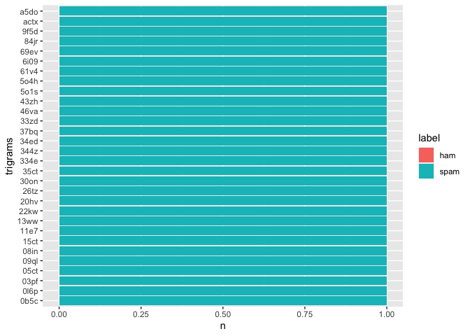

```r
top_trigrams <- emailSpamHam_train %>%
  slice(1:1000) %>%
  unnest_tokens(trigrams,
                text, token = "ngrams",
                collapse = NULL) %>%
  count(trigrams, sort = TRUE) %>%
  filter(str_detect(trigrams, "xx")) %>%
  slice(1:30)

plot_data <- emailSpamHam_train %>%
  unnest_tokens(trigrams,
                text, token = "ngrams",
                collapse = NULL) %>%
  right_join(top_trigrams, by = "trigrams") %>%
  count(trigrams, label, .drop = FALSE)

plot_data %>%
  ggplot(aes(n, trigrams, fill = label)) +
  scale_y_discrete(label=abbreviate) +
  geom_col(position = "fill")
```

Pre-process the data to prepare it for modeling. The recipes package, part of tidymodels, creates a specification of preprocessing steps that we want to perform.

- initialize the pre-processsing transformation with the recipe() function.
- tokenize text
- filter text to max tokens

```r
emailSpamHam_rec <-
  recipe(label ~ text, data = emailSpamHam_train)

emailSpamHam_rec <- emailSpamHam_rec %>%
  step_tokenize(text) %>%
  step_tokenfilter(text, max_tokens = 1e3) %>%
  step_tfidf(text)
```

# Analysis

## Build Model

Build a binary classification model the predicts the label for an email document. Use the tidymodels workflow() to bundle together our modeling components. Set the mode to classification and the model to naive Bayes.

```r
emailSpamHam_wf <- workflow() %>%
  add_recipe(emailSpamHam_rec)


nb_spec <- naive_Bayes() %>%
  set_mode("classification") %>%
  set_engine("naivebayes")

nb_spec
```

```
## Naive Bayes Model Specification (classification)
##
## Computational engine: naivebayes
```

Fit the classification model and add the nb model to our workflow

```r
nb_fit <- emailSpamHam_wf %>%
  add_model(nb_spec) %>%
  fit(data = emailSpamHam_train)


set.seed(234)
emailSpamHam_folds <- vfold_cv(emailSpamHam_train)

emailSpamHam_folds
```

```
## #  10-fold cross-validation
## # A tibble: 10 × 2
##    splits           id
##    <list>           <chr>
##  1 <split [720/80]> Fold01
##  2 <split [720/80]> Fold02
##  3 <split [720/80]> Fold03
##  4 <split [720/80]> Fold04
##  5 <split [720/80]> Fold05
##  6 <split [720/80]> Fold06
##  7 <split [720/80]> Fold07
##  8 <split [720/80]> Fold08
##  9 <split [720/80]> Fold09
## 10 <split [720/80]> Fold10
```

```r
nb_wf <- workflow() %>%
  add_recipe(emailSpamHam_rec) %>%
  add_model(nb_spec)

nb_wf
```

```
## ══ Workflow ════════════════════════════════════════════════════════════════════
## Preprocessor: Recipe
## Model: naive_Bayes()
##
## ── Preprocessor ────────────────────────────────────────────────────────────────
## 3 Recipe Steps
##
## • step_tokenize()
## • step_tokenfilter()
## • step_tfidf()
##
## ── Model ───────────────────────────────────────────────────────────────────────
## Naive Bayes Model Specification (classification)
##
## Computational engine: naivebayes
```

## Test Accuracy (Resample)

Use resampling to estimate the performance of the model. Build a resample dataset from the training set. For these resamples, the average accuracy is 86.2%.

```r
nb_rs <- fit_resamples(
    nb_wf,
    emailSpamHam_folds,
    metrics = metric_set(accuracy, roc_auc, recall, precision),
    control = control_resamples(save_pred = TRUE)
)


nb_rs_metrics <- collect_metrics(nb_rs)
nb_rs_predictions <- collect_predictions(nb_rs)

nb_rs_metrics
```

```
## # A tibble: 4 × 6
##   .metric   .estimator  mean     n std_err .config
##   <chr>     <chr>      <dbl> <int>   <dbl> <chr>
## 1 accuracy  binary     0.862    10  0.0207 Preprocessor1_Model1
## 2 precision binary     0.849    10  0.0304 Preprocessor1_Model1
## 3 recall    binary     0.905    10  0.0404 Preprocessor1_Model1
## 4 roc_auc   binary     0.931    10  0.0150 Preprocessor1_Model1
```

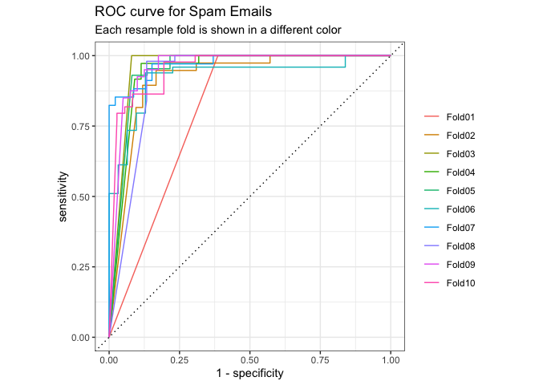

```r
nb_rs_predictions %>%
  group_by(id) %>%
  roc_curve(truth = label, .pred_ham) %>%
  autoplot() +
  labs(
    color = NULL,
    title = "ROC curve for Spam Emails",
    subtitle = "Each resample fold is shown in a different color"
  )
```

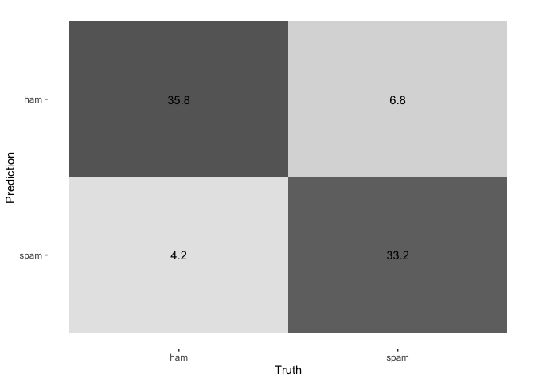

```r
conf_mat_resampled(nb_rs, tidy = FALSE) %>%
  autoplot(type = "heatmap")
```

## Test Accuracty (null model)

The model does much better than the baseling / null classification model that always predicts that largest class for classification

```r
null_classification <- null_model() %>%
  set_engine("parsnip") %>%
  set_mode("classification")

null_rs <- workflow() %>%
  add_recipe(emailSpamHam_rec) %>%
  add_model(null_classification) %>%
  fit_resamples(
    emailSpamHam_folds
  )


null_rs %>%
  collect_metrics()
```

```
## # A tibble: 2 × 6
##   .metric  .estimator  mean     n std_err .config
##   <chr>    <chr>      <dbl> <int>   <dbl> <chr>
## 1 accuracy binary     0.435    10  0.0137 Preprocessor1_Model1
## 2 roc_auc  binary     0.5      10  0      Preprocessor1_Model1
```

## Fit Test Data

```r
final_fitted <- last_fit(
    nb_wf,
    metrics = metric_set(accuracy, roc_auc, recall, precision),
    emailSpamHam_split)

(nb_rs_metrics_final <- collect_metrics(final_fitted))
```

```
## # A tibble: 4 × 4
##   .metric   .estimator .estimate .config
##   <chr>     <chr>          <dbl> <chr>
## 1 accuracy  binary         0.895 Preprocessor1_Model1
## 2 recall    binary         0.97  Preprocessor1_Model1
## 3 precision binary         0.843 Preprocessor1_Model1
## 4 roc_auc   binary         0.931 Preprocessor1_Model1
```

```r
nb_rs_predictions_final <- collect_predictions(final_fitted)
```

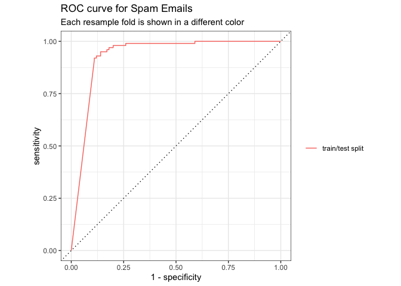

```r
nb_rs_predictions_final %>%
  group_by(id) %>%
  roc_curve(truth = label, .pred_ham) %>%
  autoplot() +
  labs(
    color = NULL,
    title = "ROC curve for Spam Emails",
    subtitle = "Each resample fold is shown in a different color"
  )
```

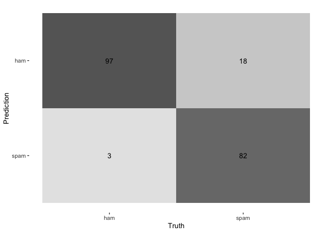

```r
nb_rs_predictions_final %>%
  conf_mat(truth = label, estimate = .pred_class) %>%
  autoplot(type = "heatmap")
```

# Conclusion

The final model had an accuracy of 89.5% on the test emails and a roc auc of 0.931. It miscalssified 3 emails as spam and 18 emaisl as ham. Overall the model performed well there are more ways to tune the model to drive more accuracy specifically filtering the emails and using the subject field for additioanl information.